## (Generalised) linear (mixed) models with R2jags: an extremely brief primer…

*Andrew Letten*

*Friday, November 28, 2014*

The purpose of this [ecostats](http://www.eco-stats.unsw.edu.au/) lab is to provide a very basic primer on running basic lm, glm and glmms in a Bayesian framework using the R2jags package (and of course JAGS). As such, the goal is not to debate the relative merits of Bayesian vs frequentist approaches, but hopefully to demystify the fitting of Bayesian models, and more specifically demonstrate that in a wide variety of (more basic) use cases the parameter estimates obtained from the two approaches are typically very similar.

We will be attempting to reproduce a small element of the analysis from a recently published article in *Journal of Ecology* (for which all the data is available at datadryad.org).

Kessler, M., Salazar, L., Homeier, J., Kluge, J. (2014), Species richness-productivity relationships of tropical terrestrial ferns at regional and local scales. *Journal of Ecology*, 102: 1623-1633. http://onlinelibrary.wiley.com/doi/10.1111/1365-2745.12299/abstract

First things first: JAGS, R packages and data.

If you don’t have it already you will need to download JAGS from http://sourceforge.net/projects/mcmc-jags/files/rjags/.

```r
# required packages
#
# install.packages("lme4")
# install.packages("R2jags")
# install.apckages("runjags")
# install.packages("coefplot2", repos="http://www.math.mcmaster.ca/bolker/R", type = "source")

library(lme4)
library(R2jags)
library(runjags)
library(coefplot2)
```

To obtain the data you can either uncomment the following code block, or alternatively proceed directly to the next block and read in ‘KessDiv.csv’ which has already been modified into a useable format.

```r
# temp <- tempfile(fileext=".csv")
# download.file(
#   "http://datadryad.org//bitstream/handle/10255/dryad.67401/Kessler Data Table.csv", temp)
# fern.dat <- read.csv(temp, header = TRUE, stringsAsFactors=FALSE)
# rm(temp)
#
# fern.dat = fern.dat[-1,]
# names(fern.dat) = c("plot", "elev", "tag", "species",
#                     "N.09", "av.09", "new.10", "N.10",
#                     "av.10", "new.11", "N.11", "av.11",
#                     "l.09", "l.10", "l.11", "prod.0910",
#                     "prod.1011", "rhz.09", "rhz.10", "rhz.11",
#                     "rhz.w", "rhz.09g", "rhz.10g", "rhz.11g",
#                     "rhz.prod.0910", "rhz.prod.1011", "arb.09", "arb.10",
#                     "arb.11", "av.diam", "t.rhz.09", "t.rhz.10",
#                     "t.rhz.11", "t.rhz.prod.0910", "t.rhz.prod.1011")
#
# fern.dat[,c(16,17,25,26)][is.na(fern.dat[,c(16,17,25,26)])] = 0 # convert productivty NAs to zero
# # length(unique(fern.dat$species)) # 88, but article says 91...
#
# library(dplyr)
# div = fern.dat %>%
#   mutate(prod = (as.numeric(prod.1011) + as.numeric(rhz.prod.1011))) %>%
#   filter(elev != 1500, elev != 3000) %>% # plots at 1500 and 3000 m appear not included?? (fig 1)
#   group_by(plot, elev) %>%
#   summarise(length(unique(species)), log(sum(prod)))
#
# colnames(div)[2:4] = c("elev", "rich", "logprod")
```

Data consists of the fern species richness and productivity sampled at 18 sites nested at 6 different elevations (i.e. three sites at each elevation.

```r
div = read.csv(file = "KessDiv.csv", header = TRUE)

div
```

```
##    plot elev rich logprod
## 1     1 4000    3   5.486
## 2    13 1000   10   5.310
## 3    14 1000    8   5.721
## 4    15 1000    9   5.295
## 5    16  500    9   6.369
## 6    17 4000    3   4.614
## 7    18 3500    6   4.070
## 8    19 4000    3   4.527
## 9     2 2000   14   6.594
## 10   20 3500    6   5.540
## 11   21 3500    5   4.405
## 12    3 2000   22   6.863
## 13    4 2500   20   8.048
## 14    5 2000   17   7.433
## 15    6 2500   19   7.667
## 16    7 2500   16   8.213
## 17    8  500   13   6.339
## 18    9  500   12   6.452
```

```r
div$elev = as.numeric(as.factor(div$elev)) # formatting for JAGS
```

**Hypothesis: There is a significant relationship between fern species richness `div$rich` and fern productivity `div$logprod`.**

*Frequentist approach*

```r
# lm
mod = lm(rich ~ logprod, data = div)
summary(mod) # -ve intercept = negative species richness at zero productivity!
```

```
##
## Call:
## lm(formula = rich ~ logprod, data = div)
##
## Residuals:
##    Min     1Q Median     3Q    Max
## -5.454 -1.704  0.579  1.282  7.763
##
## Coefficients:
##             Estimate Std. Error t value Pr(>|t|)
## (Intercept)  -14.584      3.677   -3.97   0.0011 **
## logprod        4.199      0.595    7.05  2.7e-06 ***
## ---
## Signif. codes:  0 '***' 0.001 '**' 0.01 '*' 0.05 '.' 0.1 ' ' 1
##
## Residual standard error: 3.11 on 16 degrees of freedom
## Multiple R-squared:  0.757,  Adjusted R-squared:  0.742
## F-statistic: 49.8 on 1 and 16 DF,  p-value: 2.72e-06
```

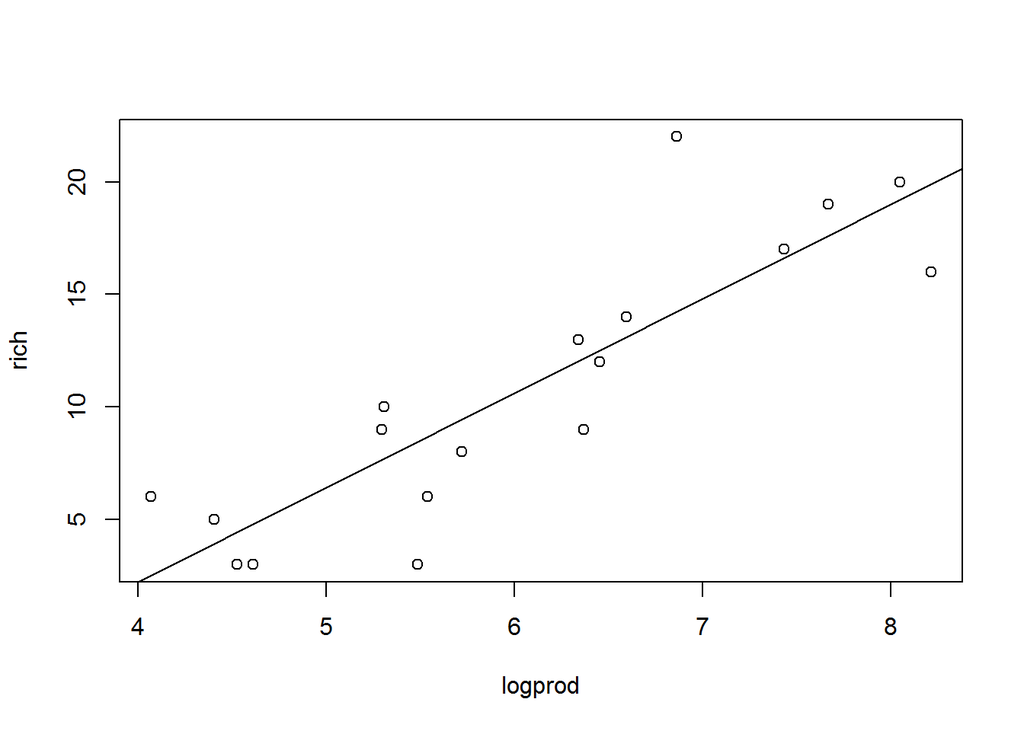

```r
plot(rich ~ logprod, data=div)
abline(mod)
```

With a random effect (intercept only) on elevation (NB: only 6 levels with 3 data points in each)

```r
# lmm
Elev = as.factor(div$elev) # back to a factor - not necessary for lmer but doing it here for peace of mind.
mixmod = lmer(rich ~ logprod + (1|Elev), data = div)
summary(mixmod) # parameter estimates same sign as original paper but different abs value (poss due to how the productivty measure was calculated)
```

```
## Linear mixed model fit by REML ['lmerMod']
## Formula: rich ~ logprod + (1 | Elev)
##    Data: div
##
## REML criterion at convergence: 87.2
##
## Scaled residuals:
##     Min      1Q  Median      3Q     Max
## -1.3761 -0.5986 -0.0094  0.5593  2.2647
##
## Random effects:
##  Groups   Name        Variance Std.Dev.
##  Elev     (Intercept) 3.32     1.82
##  Residual             7.42     2.72
## Number of obs: 18, groups: Elev, 6
##
## Fixed effects:
##             Estimate Std. Error t value
## (Intercept)  -11.857      4.671   -2.54
## logprod        3.749      0.755    4.97
##
## Correlation of Fixed Effects:
##         (Intr)
## logprod -0.978
```

*JAGS (Bayesian) approach (linear model without random effect)*

First need to bundle data into a JAGS friendly format, starting with the design matix…

```r
X = model.matrix(~ scale(logprod), data = div) #standardize (scale and centre) predictors for JAGS/BUGS analysis
X
```

```
##    (Intercept) scale(logprod)
## 1            1        -0.4471
## 2            1        -0.5857
## 3            1        -0.2615
## 4            1        -0.5977
## 5            1         0.2497
## 6            1        -1.1351
## 7            1        -1.5639
## 8            1        -1.2037
## 9            1         0.4276
## 10           1        -0.4041
## 11           1        -1.2999
## 12           1         0.6395
## 13           1         1.5741
## 14           1         1.0890
## 15           1         1.2735
## 16           1         1.7045
## 17           1         0.2259
## 18           1         0.3149
## attr(,"assign")
## [1] 0 1
```

A brief aside - remember the goal of regression is to find the best solution (parameters) to a series of linear equations (deterministic part) assumming our response is a random variable following some probability distribution (stochastic part):

```r
# deterministic & stochastic part
data.frame("y" = div$rich,
           "int" = paste(rep("  =  beta1", times = 18), "*", X[,1]),
           "beta" = rep("  +   beta2 *", times = 18),
           "x" = X[,2],
           "residuals" = paste("+   e", 1:18, sep = ""),
           row.names = paste("Obs", 1:18, "      ", sep = ""))
```

```
##              y            int          beta       x residuals
## Obs1         3   =  beta1 * 1   +   beta2 * -0.4471    +   e1
## Obs2        10   =  beta1 * 1   +   beta2 * -0.5857    +   e2
## Obs3         8   =  beta1 * 1   +   beta2 * -0.2615    +   e3
## Obs4         9   =  beta1 * 1   +   beta2 * -0.5977    +   e4
## Obs5         9   =  beta1 * 1   +   beta2 *  0.2497    +   e5
## Obs6         3   =  beta1 * 1   +   beta2 * -1.1351    +   e6
## Obs7         6   =  beta1 * 1   +   beta2 * -1.5639    +   e7
## Obs8         3   =  beta1 * 1   +   beta2 * -1.2037    +   e8
## Obs9        14   =  beta1 * 1   +   beta2 *  0.4276    +   e9
## Obs10        6   =  beta1 * 1   +   beta2 * -0.4041   +   e10
## Obs11        5   =  beta1 * 1   +   beta2 * -1.2999   +   e11
## Obs12       22   =  beta1 * 1   +   beta2 *  0.6395   +   e12
## Obs13       20   =  beta1 * 1   +   beta2 *  1.5741   +   e13
## Obs14       17   =  beta1 * 1   +   beta2 *  1.0890   +   e14
## Obs15       19   =  beta1 * 1   +   beta2 *  1.2735   +   e15
## Obs16       16   =  beta1 * 1   +   beta2 *  1.7045   +   e16
## Obs17       13   =  beta1 * 1   +   beta2 *  0.2259   +   e17
## Obs18       12   =  beta1 * 1   +   beta2 *  0.3149   +   e18
```

We can also write these equations in a more simple form using vectors and matrices, where we have a a vector consisting of the paramaters (betas) and and the matrix is the design matrix `X` we get from `model.matrix`. In the second example, we’ll take advantage of matrix algebra to simplifiy the JAGS code.

JAGS expects the data as a named list:

```r
jags.data = list(Y = div$rich,
                 X = X,
                 N = nrow(div),
                 K = ncol(X))
```

Specify the model in JAGS code. The sink and cat functions writes the model into a text file in the working directory. Something that can be confusing at first is that unlike R code which is read top to bottom, JAGS does not care about the order. As such variables may be called before they appear to have been defined. (Note the open and closing braces before and after sink are only needed when compiling an html/pdf with `knitr`, see [here](https://groups.google.com/forum/#!topic/knitr/TCz9vNLlslY)).

```r
# JAGS Code
#######################################
{sink("model.txt")
cat("
model{

    #Priors beta
    #In JAGS: dnorm(0, 1/sigma^2)
    for (i in 1:K) {beta[i] ~ dnorm(0, 0.0001)} # small precision(tau) = large variance = diffuse prior

    #Priors sigma
    tau <- 1 / (sigma * sigma)  # tau = 1/ sigma^2
    sigma ~ dunif(0.0001, 10)

    #Likelihood
    for (i in 1:N) {
      Y[i]   ~ dnorm(mu[i], tau)
      mu[i]  <- eta[i]
      eta[i] <- beta[1] * X[i,1] + beta[2] * X[i,2]

     #Residuals
     Res[i]    <- Y[i] - mu[i]
    }
}
",fill = TRUE)
sink()}
##########################################
```

Provide a function to generate inits for each parameters (can skip this for now as JAGS defaults to random starting values)

```r
# # Initial values
# inits  = function (){
#   list(beta = rnorm(ncol(X), 0, 0.01),
#        sigma = runif(1, 0.0001, 10))
#   }
```

Tell JAGS which parameters you want to save

```r
params = c("beta", "sigma", "Res", "mu")
```

Finally, call JAGS using the `jags` function in R2Jags

```r
fitmod = jags(data = jags.data,
              # inits = inits,
              parameters = params,
              model = "model.txt",
              n.chains = 3,
              n.thin = 10,
              n.iter = 5000,
              n.burnin = 1000)
```

```
## module glm loaded
```

Extract output…

```r
out = fitmod$BUGSoutput # output in WinBUGS format
out
```

```
## Inference for Bugs model at "model.txt", fit using jags,
##  3 chains, each with 5000 iterations (first 1000 discarded), n.thin = 10
##  n.sims = 1200 iterations saved
##          mean  sd 2.5%  25%  50%  75% 97.5% Rhat n.eff
## Res[1]   -5.5 0.9 -7.2 -6.1 -5.5 -4.9  -3.7    1  1200
## Res[2]    2.3 0.9  0.5  1.6  2.3  2.9   4.2    1  1200
## Res[3]   -1.4 0.8 -3.1 -2.0 -1.5 -0.9   0.2    1  1200
## Res[4]    1.3 1.0 -0.5  0.7  1.3  2.0   3.3    1  1100
## Res[5]   -3.2 0.9 -4.8 -3.7 -3.1 -2.6  -1.5    1  1200
## Res[6]   -1.8 1.2 -4.2 -2.6 -1.8 -1.0   0.6    1   680
## Res[7]    3.5 1.5  0.5  2.4  3.5  4.5   6.4    1   570
## Res[8]   -1.5 1.3 -3.9 -2.3 -1.4 -0.6   1.1    1   650
## Res[9]    0.9 0.9 -0.9  0.3  0.9  1.5   2.8    1  1200
## Res[10]  -2.7 0.9 -4.4 -3.3 -2.7 -2.1  -1.0    1  1200
## Res[11]   1.1 1.4 -1.6  0.2  1.1  2.0   3.7    1   620
## Res[12]   7.8 1.0  5.7  7.1  7.8  8.4   9.8    1  1200
## Res[13]   0.8 1.6 -2.4 -0.2  0.8  1.9   4.0    1   580
## Res[14]   0.4 1.3 -2.1 -0.4  0.4  1.2   2.8    1   710
## Res[15]   1.4 1.4 -1.4  0.5  1.4  2.3   4.1    1   650
## Res[16]  -3.9 1.7 -7.2 -5.0 -3.9 -2.8  -0.6    1   560
## Res[17]   1.0 0.9 -0.7  0.4  1.0  1.5   2.7    1  1200
## Res[18]  -0.5 0.9 -2.2 -1.1 -0.5  0.1   1.3    1  1200
## beta[1]  10.8 0.8  9.2 10.3 10.8 11.4  12.4    1  1200
## beta[2]   5.3 0.9  3.6  4.7  5.3  5.9   7.0    1   530
## deviance 93.4 2.7 90.1 91.4 92.7 94.7 100.2    1  1200
## mu[1]     8.5 0.9  6.7  7.9  8.5  9.1  10.2    1  1200
## mu[2]     7.7 0.9  5.8  7.1  7.7  8.4   9.5    1   970
## mu[3]     9.4 0.8  7.8  8.9  9.5 10.0  11.1    1  1200
## mu[4]     7.7 1.0  5.7  7.0  7.7  8.3   9.5    1   950
## mu[5]    12.2 0.9 10.5 11.6 12.1 12.7  13.8    1  1200
## mu[6]     4.8 1.2  2.4  4.0  4.8  5.6   7.2    1   490
## mu[7]     2.5 1.5 -0.4  1.5  2.5  3.6   5.5    1   570
## mu[8]     4.5 1.3  1.9  3.6  4.4  5.3   6.9    1   650
## mu[9]    13.1 0.9 11.2 12.5 13.1 13.7  14.9    1  1200
## mu[10]    8.7 0.9  7.0  8.1  8.7  9.3  10.4    1  1200
## mu[11]    3.9 1.4  1.3  3.0  3.9  4.8   6.6    1   620
## mu[12]   14.2 1.0 12.2 13.6 14.2 14.9  16.3    1  1000
## mu[13]   19.2 1.6 16.0 18.1 19.2 20.2  22.4    1   600
## mu[14]   16.6 1.3 14.2 15.8 16.6 17.4  19.1    1   710
## mu[15]   17.6 1.4 14.9 16.7 17.6 18.5  20.4    1   650
## mu[16]   19.9 1.7 16.6 18.8 19.9 21.0  23.2    1   580
## mu[17]   12.0 0.9 10.3 11.5 12.0 12.6  13.7    1  1200
## mu[18]   12.5 0.9 10.7 11.9 12.5 13.1  14.2    1  1200
## sigma     3.4 0.6  2.4  2.9  3.3  3.7   4.8    1  1200
##
## For each parameter, n.eff is a crude measure of effective sample size,
## and Rhat is the potential scale reduction factor (at convergence, Rhat=1).
##
## DIC info (using the rule, pD = var(deviance)/2)
## pD = 3.7 and DIC = 97.1
## DIC is an estimate of expected predictive error (lower deviance is better).
```

Check mixing/convergence of betas (intercept and slope)…

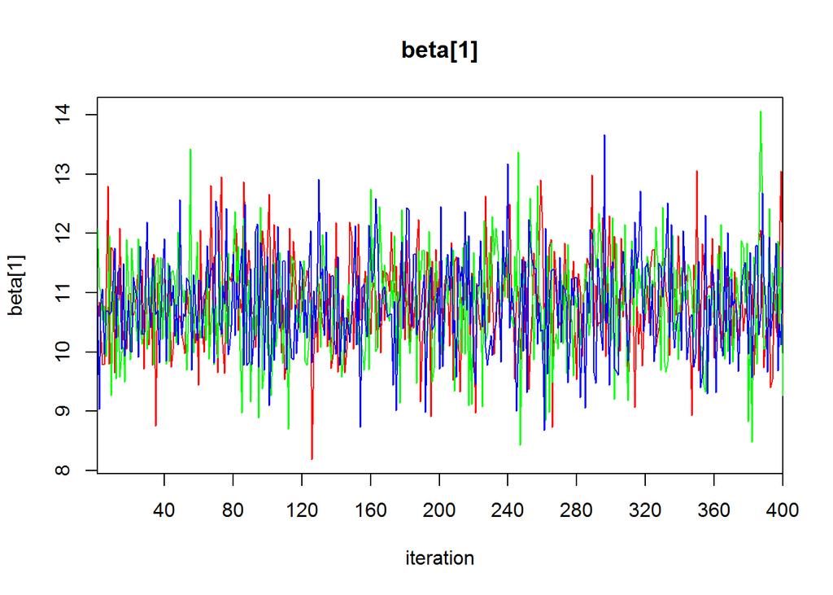

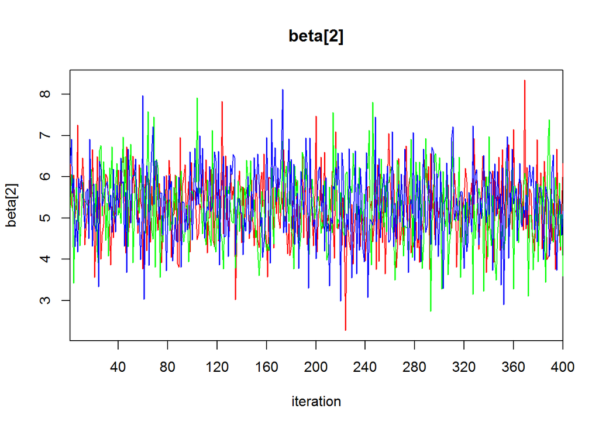

```r
traceplot(fitmod, varname = c("beta"))
```

Check density plots

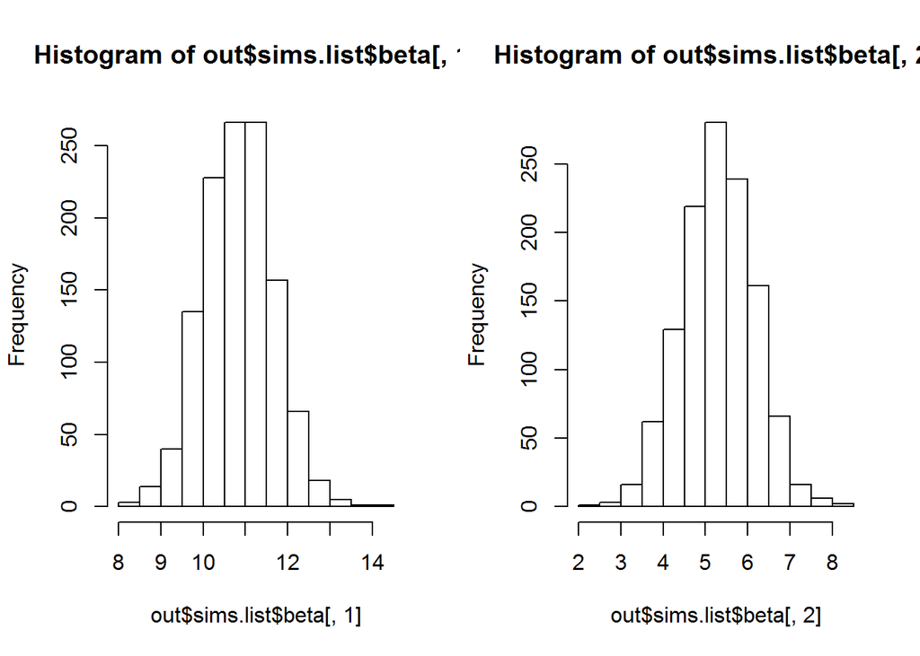

```r
par(mfrow = c(1,2))
hist(out$sims.list$beta[,1])
abline(v = 0, col = "red")

hist(out$sims.list$beta[,2])
abline(v = 0, col = "red")
```

```r
dev.off()
```

Beta coefs and credible intervals

```r
my.coefs = out$summary[c("beta[1]", "beta[2]"),c(1:3,7)]
my.coefs
```

```
##           mean     sd  2.5%  97.5%
## beta[1] 10.834 0.8223 9.205 12.438
## beta[2]  5.303 0.8542 3.643  6.952
```

Compare with results using lm above

```r
mod = lm(rich ~ scale(logprod), data = div) # this time with standardized predictors
summary(mod)
```

```
##
## Call:
## lm(formula = rich ~ scale(logprod), data = div)
##
## Residuals:
##    Min     1Q Median     3Q    Max
## -5.454 -1.704  0.579  1.282  7.763
##
## Coefficients:
##                Estimate Std. Error t value Pr(>|t|)
## (Intercept)      10.833      0.733   14.77  9.6e-11 ***
## scale(logprod)    5.323      0.755    7.05  2.7e-06 ***
## ---
## Signif. codes:  0 '***' 0.001 '**' 0.01 '*' 0.05 '.' 0.1 ' ' 1
##
## Residual standard error: 3.11 on 16 degrees of freedom
## Multiple R-squared:  0.757,  Adjusted R-squared:  0.742
## F-statistic: 49.8 on 1 and 16 DF,  p-value: 2.72e-06
```

```r
cbind(coef(mod), my.coefs[,1])
```

```
##                  [,1]   [,2]
## (Intercept)    10.833 10.834
## scale(logprod)  5.323  5.303
```

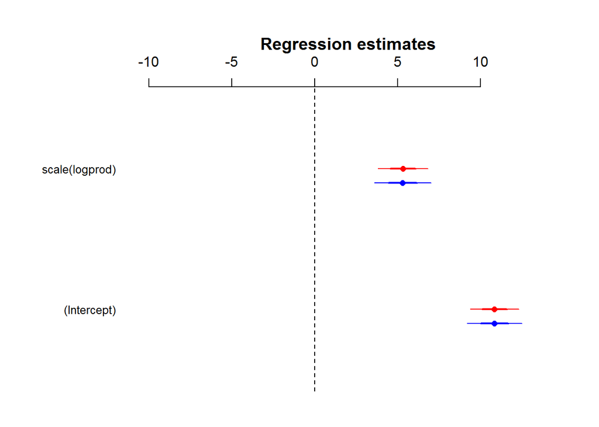

```r
# coef plots
mod.beta.freq = coef(mod)
mod.se.freq = sqrt(diag(vcov(mod)))
mod.beta.jags = my.coefs[,1]
mod.se.jags = my.coefs[,2]

par(mfrow = c(1,1))
coefplot2(mod.beta.freq, mod.se.freq, col = "red", varnames = names(mod.beta.freq), xlim = c(-10,14))
coefplot2(mod.beta.jags, mod.se.jags, col = "blue", varnames = names(mod.beta.freq), add = TRUE, offset = -0.1)
```

Don’t forget model checks, e.g. residual plots:

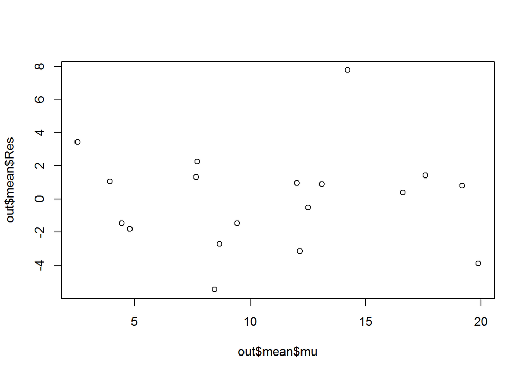

```r
plot(out$mean$mu, out$mean$Res)
```

Now with elevation treated as a random effect (intercept only)…

```r
# Bundle data for JAGS
# Random effects:
Nre = length(unique(div$elev))
jags.data <- list(Y = div$rich,
                 X = X,
                 N = nrow(div),
                 K = ncol(X),
                 Elev = div$elev,
                 Nre = Nre)
```

Specify model - only need to modify a few lines of code to include the random effect.

```r
###################################################
# JAGS code
{sink("mixedmodel.txt")
cat("
    model{
    # Priors beta and sigma
    for (i in 1:K) {beta[i] ~ dnorm(0, 0.0001)}
    tau  <- 1 / (sigma * sigma)
    sigma ~ dunif(0.0001, 20)

    # Priors random effects and sigma_Elev
    for (i in 1:Nre) {a[i] ~ dnorm(0, tau_Elev)}
    tau_Elev <- 1 / (sigma_Elev * sigma_Elev)
    sigma_Elev ~ dunif(0.0001, 20)

    # Likelihood
    for (i in 1:N) {
    Y[i]    ~ dnorm(mu[i], tau)
    mu[i]  <- eta[i] + a[Elev[i]] # random intercept
    eta[i] <- inprod(beta[], X[i,])

    # Residuals
    Res[i]    <- Y[i] - mu[i]
    }
    }
    ",fill = TRUE)
sink()}
##############################################
```

Initial values, parameters to save etc.

```r
# # Initial values
# inits = function () {
#   list(
#     beta = rnorm(ncol(X), 0, 0.01),
#     sigma = runif(1, 0.0001, 20),
#     a = rnorm(Nre, 0, 0.01),
#     sigma_Elev = runif(1, 0.0001, 20))}

# Parameters to save
params = c("beta", "sigma", "Res", "a", "sigma_Elev", "mu", "eta")
```

Run JAGS, run…

```r
fit.mixmod = jags(data = jags.data,
           # inits = inits,
           parameters = params,
           model = "mixedmodel.txt",
           n.chains = 3,
           n.thin = 10,
           n.iter = 5000,
           n.burnin = 1000)
```

Check output

```r
out = fit.mixmod$BUGSoutput
print(out, digits = 3)
```

```
## Inference for Bugs model at "mixedmodel.txt", fit using jags,
##  3 chains, each with 5000 iterations (first 1000 discarded), n.thin = 10
##  n.sims = 1200 iterations saved
##              mean    sd    2.5%    25%    50%    75%  97.5%  Rhat n.eff
## Res[1]     -3.009 2.113  -6.726 -4.564 -3.134 -1.544  1.183 1.008   230
## Res[2]      1.530 1.467  -1.719  0.608  1.575  2.433  4.292 1.002   760
## Res[3]     -1.666 1.419  -4.668 -2.554 -1.659 -0.796  1.102 1.001  1200
## Res[4]      0.574 1.475  -2.746 -0.351  0.624  1.491  3.324 1.003   750
## Res[5]     -2.567 1.406  -5.326 -3.476 -2.583 -1.716  0.421 1.001  1200
## Res[6]     -0.471 1.628  -3.570 -1.554 -0.499  0.597  2.762 1.005   370
## Res[7]      2.125 1.910  -1.658  0.818  2.173  3.348  5.961 1.004   460
## Res[8]     -0.218 1.637  -3.332 -1.308 -0.242  0.848  3.126 1.005   430
## Res[9]     -1.322 1.927  -5.018 -2.747 -1.225  0.196  2.165 1.003   540
## Res[10]    -2.154 1.798  -5.443 -3.354 -2.215 -1.089  1.601 1.000  1200
## Res[11]     0.151 1.611  -3.077 -0.805  0.208  1.159  3.342 1.003   570
## Res[12]     5.896 1.732   2.631  4.660  5.905  7.196  9.112 1.003   680
## Res[13]     1.499 1.677  -1.884  0.501  1.494  2.565  4.674 1.004   530
## Res[14]    -0.762 1.641  -4.279 -1.776 -0.729  0.356  2.284 1.001  1200
## Res[15]     1.608 1.584  -1.457  0.625  1.604  2.622  4.676 1.005   390
## Res[16]    -2.983 1.781  -6.548 -4.017 -2.923 -1.854  0.328 1.003   610
## Res[17]     1.521 1.401  -1.220  0.629  1.513  2.352  4.459 1.001  1200
## Res[18]     0.193 1.429  -2.667 -0.708  0.182  1.062  3.255 1.001  1200
## a[1]       -0.259 2.462  -5.096 -1.341 -0.150  0.887  5.605 1.001  1200
## a[2]       -0.273 2.518  -6.615 -1.179 -0.012  1.002  4.426 1.005  1200
## a[3]        2.840 3.045  -1.248  0.628  2.116  4.475 10.441 1.001  1200
## a[4]        1.789 3.430  -2.972 -0.298  0.866  3.443 10.797 1.003   980
## a[5]       -1.259 3.169  -9.039 -2.514 -0.491  0.535  3.699 1.005  1200
## a[6]       -3.246 3.514 -11.829 -4.956 -2.328 -0.665  1.245 1.008   250
## beta[1]    10.904 2.215   6.151  9.818 10.843 11.790 15.962 1.006  1200
## beta[2]     3.689 2.011  -0.816  2.481  4.064  5.139  6.781 1.003   630
## deviance   87.204 6.172  75.704 82.559 87.764 91.546 98.594 1.002   780
## eta[1]      9.255 2.453   5.216  7.978  8.905 10.068 15.564 1.007   840
## eta[2]      8.743 2.587   4.669  7.308  8.293  9.669 15.228 1.007   730
## eta[3]      9.939 2.316   5.698  8.735  9.701 10.804 15.767 1.015  1200
## eta[4]      8.699 2.600   4.693  7.247  8.242  9.644 15.197 1.007   720
## eta[5]     11.826 2.234   6.450 10.803 11.918 12.891 16.258 1.006  1200
## eta[6]      6.717 3.300   2.065  4.665  5.985  8.142 15.020 1.006   560
## eta[7]      5.134 3.983  -0.440  2.477  4.222  6.889 15.480 1.005   520
## eta[8]      6.463 3.404   1.658  4.308  5.728  7.912 15.129 1.006   550
## eta[9]     12.482 2.314   6.934 11.430 12.709 13.733 16.546 1.007  1200
```

[output cut: 21 more lines]

```
## mu[13]     18.501 1.677  15.326 17.435 18.506 19.499 21.884 1.004   500
## mu[14]     17.762 1.641  14.716 16.644 17.729 18.776 21.279 1.001  1200
## mu[15]     17.392 1.584  14.324 16.378 17.396 18.375 20.457 1.007   360
## mu[16]     18.983 1.781  15.672 17.854 18.923 20.017 22.548 1.003   590
## mu[17]     11.479 1.401   8.541 10.648 11.487 12.371 14.220 1.002  1200
## mu[18]     11.807 1.429   8.745 10.938 11.818 12.708 14.667 1.001  1200
## sigma       2.893 0.713   1.758  2.377  2.815  3.296  4.528 1.001  1200
## sigma_Elev  3.719 3.193   0.215  1.469  2.795  5.001 12.784 1.014   220
##
## For each parameter, n.eff is a crude measure of effective sample size,
## and Rhat is the potential scale reduction factor (at convergence, Rhat=1).
##
## DIC info (using the rule, pD = var(deviance)/2)
## pD = 19.0 and DIC = 106.2
## DIC is an estimate of expected predictive error (lower deviance is better).
```

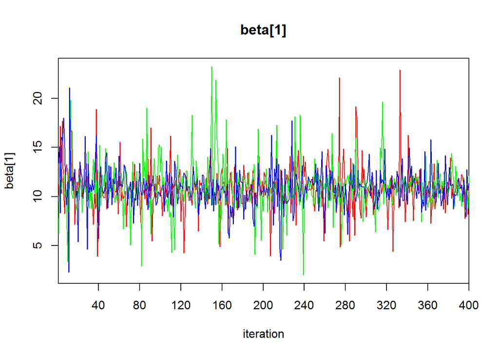

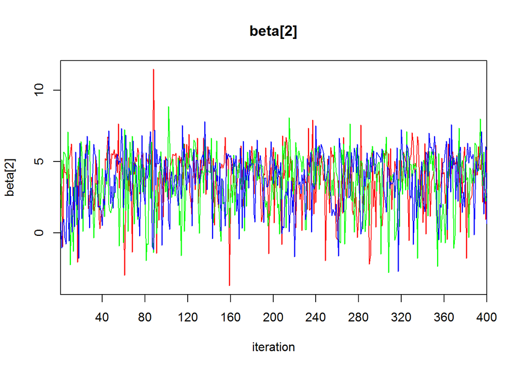

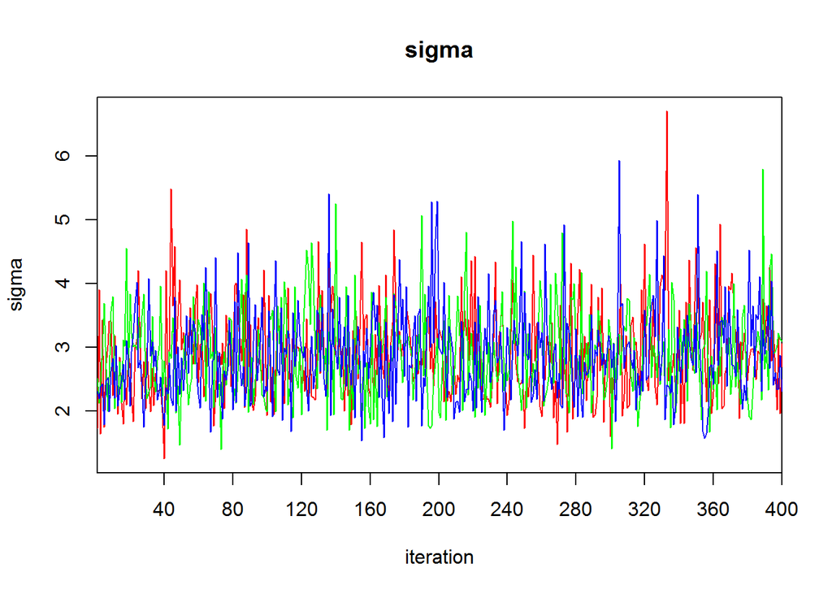

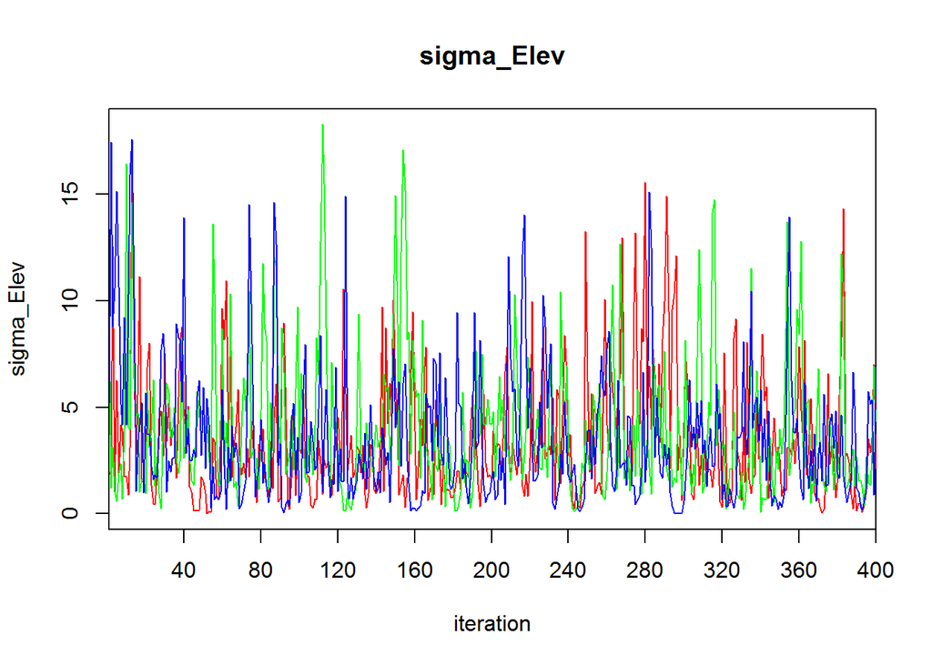

```r
# Assess mixing/convergence
traceplot(fit.mixmod, varname = c("beta","sigma","sigma_Elev"))
```

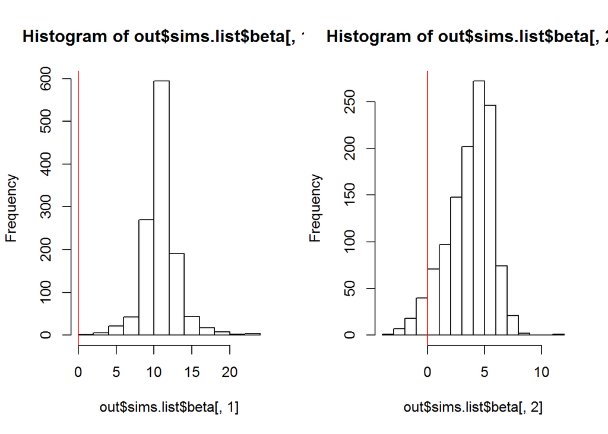

```r
# Check histograms
par(mfrow = c(1,2))
hist(out$sims.list$beta[,1])
abline(v = 0, col = "red")

hist(out$sims.list$beta[,2])
abline(v = 0, col = "red")
```

```r
dev.off()
```

There are many ways to extract different the same informationg for the output object. Before we just grabbed summary data, but we can also grab the MCMC iterations and perform our own sumamry analyses.

```r
# extract mcmc samples
all.mcmc = mcmc(out$sims.matrix) # combine chains together
dim(all.mcmc)
```

```
## [1] 1200   65
```

```r
colnames(all.mcmc)
```

```
##  [1] "Res[1]"     "Res[2]"     "Res[3]"     "Res[4]"     "Res[5]"
##  [6] "Res[6]"     "Res[7]"     "Res[8]"     "Res[9]"     "Res[10]"
## [11] "Res[11]"    "Res[12]"    "Res[13]"    "Res[14]"    "Res[15]"
## [16] "Res[16]"    "Res[17]"    "Res[18]"    "a[1]"       "a[2]"
## [21] "a[3]"       "a[4]"       "a[5]"       "a[6]"       "beta[1]"
## [26] "beta[2]"    "deviance"   "eta[1]"     "eta[2]"     "eta[3]"
## [31] "eta[4]"     "eta[5]"     "eta[6]"     "eta[7]"     "eta[8]"
## [36] "eta[9]"     "eta[10]"    "eta[11]"    "eta[12]"    "eta[13]"
## [41] "eta[14]"    "eta[15]"    "eta[16]"    "eta[17]"    "eta[18]"
## [46] "mu[1]"      "mu[2]"      "mu[3]"      "mu[4]"      "mu[5]"
## [51] "mu[6]"      "mu[7]"      "mu[8]"      "mu[9]"      "mu[10]"
## [56] "mu[11]"     "mu[12]"     "mu[13]"     "mu[14]"     "mu[15]"
## [61] "mu[16]"     "mu[17]"     "mu[18]"     "sigma"      "sigma_Elev"
```

```r
# all.a = all.mcmc[,grep("a",colnames(all.mcmc))] # alternatively out$sims.list$a
all.beta = all.mcmc[,grep("beta",colnames(all.mcmc))] # alternatively out$sims.list$beta
# all.sigma.elev = all.mcmc[,grep("sigma_Elev",colnames(all.mcmc))] # alternatively out$sims.list$sigma_Elev
```

Compare with lmer…

```r
mixmod = lmer(rich ~ scale(logprod) + (1|elev), data = div, REML = TRUE) # standardized predictors
summary(mixmod)
```

```
## Linear mixed model fit by REML ['lmerMod']
## Formula: rich ~ scale(logprod) + (1 | elev)
##    Data: div
##
## REML criterion at convergence: 86.7
##
## Scaled residuals:
##     Min      1Q  Median      3Q     Max
## -1.3761 -0.5986 -0.0094  0.5593  2.2647
##
## Random effects:
##  Groups   Name        Variance Std.Dev.
##  elev     (Intercept) 3.32     1.82
##  Residual             7.42     2.72
## Number of obs: 18, groups: elev, 6
##
## Fixed effects:
##                Estimate Std. Error t value
## (Intercept)      10.833      0.983   11.02
## scale(logprod)    4.752      0.956    4.97
##
## Correlation of Fixed Effects:
##             (Intr)
## scal(lgprd) 0.000
```

```r
apply(all.beta,2,mean)
```

```
## beta[1] beta[2]
##  10.904   3.689
```

```r
cbind(fixef(mixmod), apply(all.beta,2,mean))
```

```
##                  [,1]   [,2]
## (Intercept)    10.833 10.904
## scale(logprod)  4.752  3.689
```

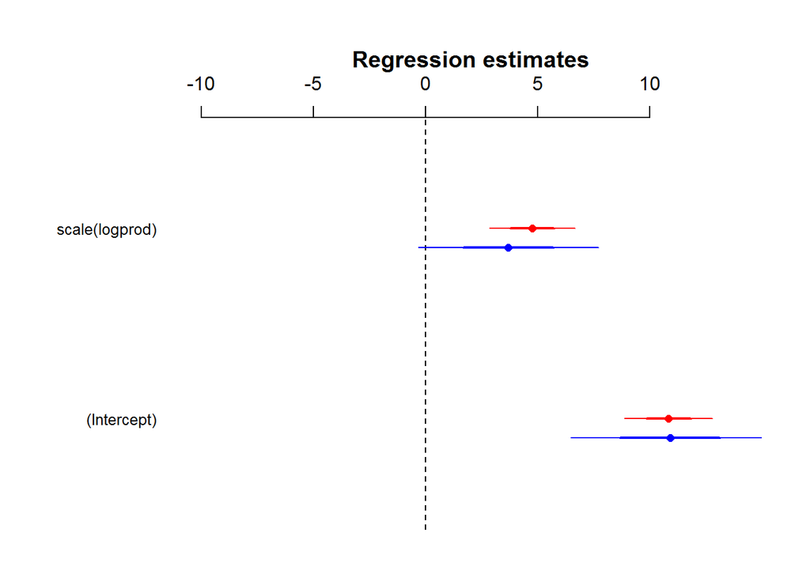

```r
# coef plots
mixmod.beta.freq = fixef(mixmod)
mixmod.se.freq = sqrt(diag(vcov(mixmod)))
mixmod.beta.jags = apply(all.beta,2,mean)
mixmod.se.jags = apply(all.beta,2, sd)

coefplot2(mixmod.beta.freq, mixmod.se.freq, col = "red", varnames = names(mod.beta.freq), xlim = c(-10,14))
coefplot2(mixmod.beta.jags, mixmod.se.jags, col = "blue", varnames = names(mod.beta.freq), add = TRUE, offset = -0.1)
```

Maybe should have used a different distribution given the response is counts of species richness (e.g. Possion or negative binomial)?

```r
mixmod.pois = glmer(rich ~ scale(logprod) + (1|elev), data = div, family = "poisson")
summary(mixmod.pois)
```

```
## Generalized linear mixed model fit by maximum likelihood (Laplace
##   Approximation) [glmerMod]
##  Family: poisson ( log )
## Formula: rich ~ scale(logprod) + (1 | elev)
##    Data: div
##
##      AIC      BIC   logLik deviance df.resid
##     95.5     98.2    -44.8     89.5       15
##
## Scaled residuals:
##    Min     1Q Median     3Q    Max
## -1.461 -0.629  0.022  0.535  1.935
##
## Random effects:
##  Groups Name        Variance Std.Dev.
##  elev   (Intercept) 0.0158   0.126
## Number of obs: 18, groups: elev, 6
##
## Fixed effects:
##                Estimate Std. Error z value Pr(>|z|)
## (Intercept)      2.2557     0.0971   23.22  < 2e-16 ***
## scale(logprod)   0.4921     0.0942    5.22  1.8e-07 ***
## ---
## Signif. codes:  0 '***' 0.001 '**' 0.01 '*' 0.05 '.' 0.1 ' ' 1
##
## Correlation of Fixed Effects:
##             (Intr)
## scal(lgprd) -0.288
```

```r
#################################################################
# JAGS code
{sink("genmixedmodel.txt")
cat("
    model{
    # Priors beta
    for (i in 1:K) {beta[i] ~ dnorm(0, 0.0001)}

    # Priors random effects and sigma_Elev
    for (i in 1:Nre) {a[i] ~ dnorm(0, tau_Elev)}
    tau_Elev <- 1 / (sigma_Elev * sigma_Elev)
    sigma_Elev ~ dunif(0.0001, 20)

    # Likelihood
    for (i in 1:N) {
    Y[i]   ~ dpois(mu[i])
    log(mu[i]) <- eta[i] # in jags you have to specify the link function
    eta[i] <- inprod(beta[], X[i,]) + a[Elev[i]]

    # Residuals
    Res[i]    <- Y[i] - mu[i]
    }
    }
    ",fill = TRUE)
sink()}
############################################################

# Initial values & parameters to save
# inits  = function () {
#   list(
#     beta       = rnorm(ncol(X), 0, 0.01),
#     a          = rnorm(Nre, 0, 0.01),
#     sigma_Elev = runif(1, 0.0001, 20))  }

params = c("beta", "Res", "a", "sigma_Elev", "mu", "eta")
```

```r
# Start JAGS
fit.mixpois = jags(data       = jags.data,
           # inits = inits,
           parameters = params,
           model = "genmixedmodel.txt",
           n.thin = 10,
           n.chains = 3,
           n.burnin = 1000,
           n.iter = 5000)
```

In case of lack of convergence - update on the fly!

```r
fit.mixpois = update(fit.mixpois, n.iter = 10000, n.thin = 10) #
```

Check output…

```r
out = fit.mixpois$BUGSoutput
print(out, digits = 3)
```

```
## Inference for Bugs model at "genmixedmodel.txt", fit using jags,
##  3 chains, each with 10000 iterations (first 5000 discarded), n.thin = 10
##  n.sims = 3000 iterations saved
##              mean    sd    2.5%    25%    50%    75%  97.5%  Rhat n.eff
## Res[1]     -2.238 1.675  -5.515 -3.453 -2.190 -0.957  0.788 1.001  3000
## Res[2]      1.819 1.511  -1.530  0.897  1.984  2.875  4.333 1.001  2300
## Res[3]     -1.266 1.620  -4.873 -2.233 -1.127 -0.128  1.469 1.001  3000
## Res[4]      0.856 1.510  -2.504 -0.065  1.021  1.910  3.364 1.001  2200
## Res[5]     -2.102 1.668  -5.653 -3.112 -1.996 -0.936  0.950 1.001  3000
## Res[6]     -0.967 1.164  -3.337 -1.756 -0.910 -0.118  1.100 1.001  3000
## Res[7]      1.202 1.210  -1.724  0.516  1.345  2.064  3.134 1.001  2300
## Res[8]     -0.861 1.132  -3.132 -1.629 -0.815 -0.033  1.127 1.001  3000
## Res[9]     -0.718 2.348  -6.077 -2.109 -0.472  0.947  3.095 1.001  2200
## Res[10]    -1.485 1.605  -4.899 -2.478 -1.484 -0.427  1.677 1.001  3000
## Res[11]    -0.286 1.185  -3.029 -0.957 -0.163  0.538  1.694 1.001  3000
## Res[12]     6.054 2.273   1.123  4.590  6.217  7.691  9.999 1.001  3000
## Res[13]     1.046 2.492  -4.096 -0.586  1.084  2.817  5.530 1.002  1800
## Res[14]    -2.010 2.824  -7.979 -3.793 -1.738 -0.061  3.076 1.001  3000
## Res[15]     2.154 2.102  -2.157  0.755  2.181  3.650  5.958 1.001  3000
## Res[16]    -3.969 2.839 -10.029 -5.834 -3.897 -1.939  1.134 1.002  1400
## Res[17]     2.001 1.655  -1.551  0.997  2.114  3.174  5.015 1.001  2900
## Res[18]     0.613 1.714  -3.045 -0.457  0.711  1.793  3.727 1.001  3000
## a[1]        0.073 0.278  -0.433 -0.070  0.040  0.198  0.707 1.003  3000
## a[2]        0.087 0.284  -0.451 -0.052  0.069  0.230  0.654 1.002  3000
## a[3]        0.284 0.316  -0.151  0.080  0.228  0.430  1.040 1.002  3000
## a[4]        0.095 0.376  -0.457 -0.112  0.013  0.234  1.062 1.001  3000
## a[5]       -0.080 0.335  -0.875 -0.223 -0.034  0.090  0.521 1.001  3000
## a[6]       -0.453 0.428  -1.482 -0.670 -0.374 -0.140  0.076 1.001  3000
## beta[1]     2.226 0.246   1.689  2.123  2.236  2.347  2.679 1.003  3000
## beta[2]     0.389 0.197  -0.081  0.287  0.424  0.521  0.698 1.002  1400
## deviance   85.802 4.050  79.177 82.782 85.397 88.490 94.602 1.001  3000
## eta[1]      1.599 0.351   0.794  1.375  1.647  1.865  2.142 1.001  3000
## eta[2]      2.085 0.182   1.735  1.964  2.081  2.209  2.445 1.001  3000
## eta[3]      2.211 0.173   1.877  2.095  2.211  2.326  2.555 1.001  3000
## eta[4]      2.081 0.183   1.729  1.959  2.077  2.204  2.443 1.001  3000
## eta[5]      2.396 0.151   2.086  2.296  2.398  2.494  2.685 1.001  3000
## eta[6]      1.331 0.314   0.642  1.137  1.364  1.559  1.846 1.001  3000
## eta[7]      1.537 0.248   1.053  1.370  1.538  1.702  2.044 1.001  3000
## eta[8]      1.305 0.314   0.627  1.110  1.339  1.532  1.814 1.001  3000
## eta[9]      2.677 0.157   2.389  2.569  2.672  2.779  3.000 1.001  2100
```

[output cut: 20 more lines]

```
## mu[12]     15.946 2.273  12.001 14.309 15.783 17.410 20.877 1.001  3000
## mu[13]     18.954 2.492  14.470 17.183 18.916 20.586 24.096 1.002  1800
## mu[14]     19.010 2.824  13.924 17.061 18.738 20.793 24.979 1.001  3000
## mu[15]     16.846 2.102  13.042 15.350 16.819 18.245 21.157 1.001  3000
## mu[16]     19.969 2.839  14.866 17.939 19.897 21.834 26.029 1.002  1400
## mu[17]     10.999 1.655   7.985  9.826 10.886 12.003 14.551 1.001  3000
## mu[18]     11.387 1.714   8.273 10.207 11.289 12.457 15.045 1.002  3000
## sigma_Elev  0.439 0.373   0.030  0.199  0.348  0.562  1.437 1.002  1900
##
## For each parameter, n.eff is a crude measure of effective sample size,
## and Rhat is the potential scale reduction factor (at convergence, Rhat=1).
##
## DIC info (using the rule, pD = var(deviance)/2)
## pD = 8.2 and DIC = 94.0
## DIC is an estimate of expected predictive error (lower deviance is better).
```

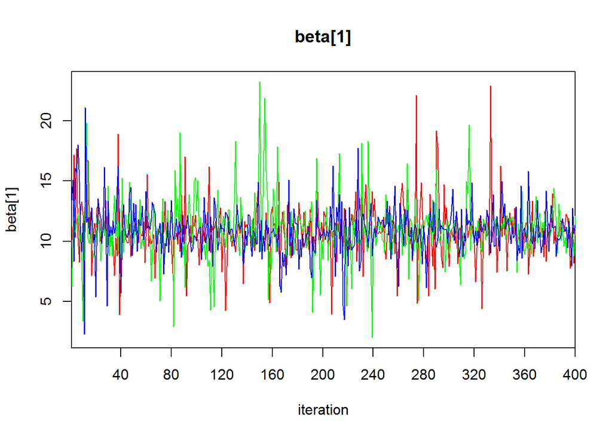

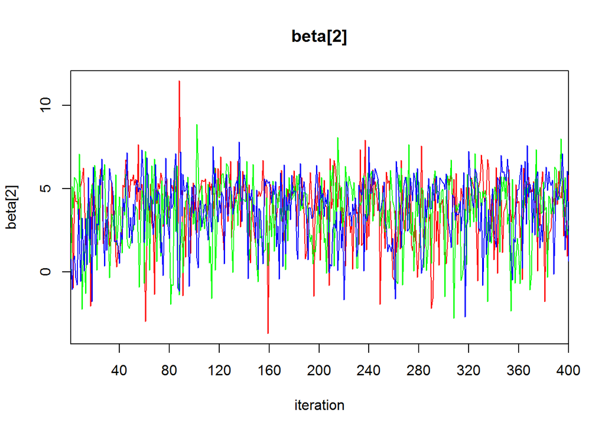

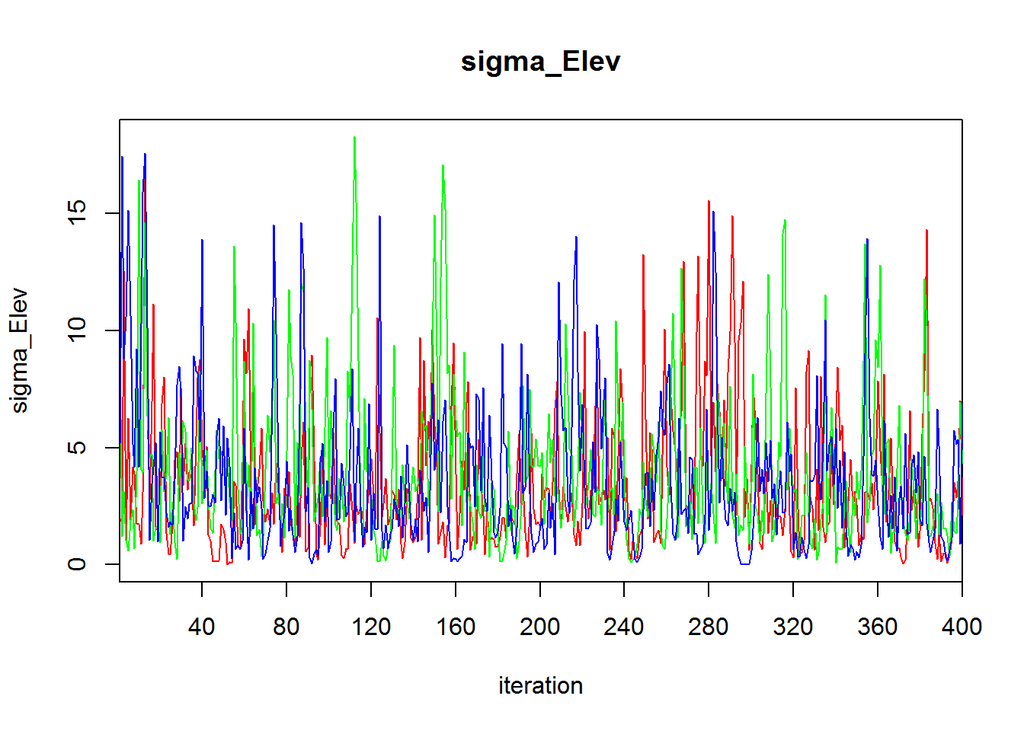

```r
# Check mixing/convergence
traceplot(fit.mixmod, varname = c("beta","sigma_Elev"))
```

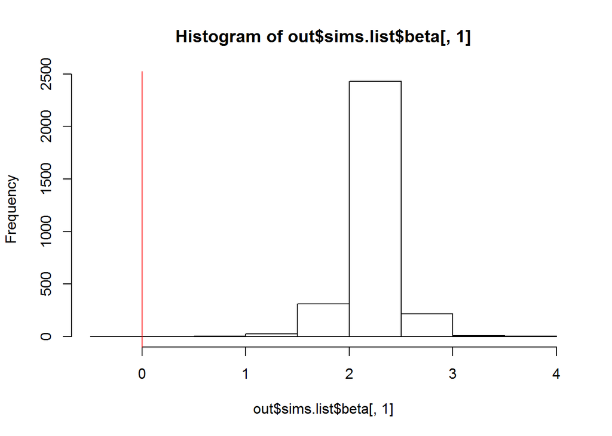

```r
# Check histograms
hist(out$sims.list$beta[,1])
abline(v = 0, col = "red")
```

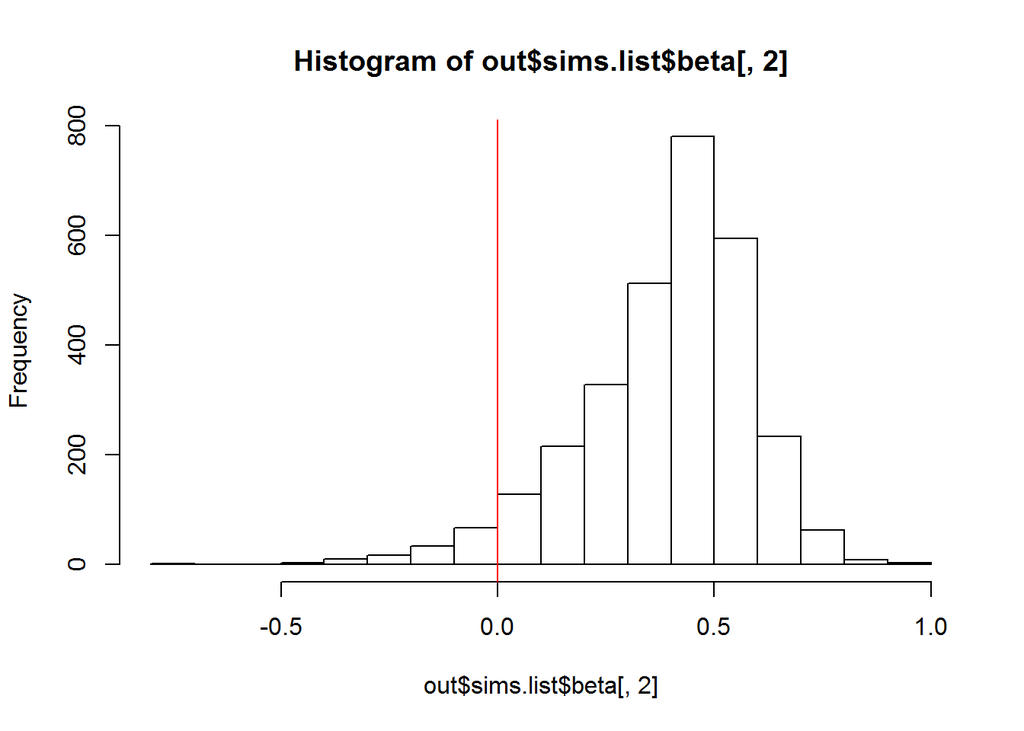

```r
hist(out$sims.list$beta[,2])
abline(v = 0, col = "red")
```

```r
# Extract mcmc samples
all.mcmc = mcmc(out$sims.matrix)
dim(all.mcmc)
```

```
## [1] 3000   64
```

```r
colnames(all.mcmc)
```

```
##  [1] "Res[1]"     "Res[2]"     "Res[3]"     "Res[4]"     "Res[5]"
##  [6] "Res[6]"     "Res[7]"     "Res[8]"     "Res[9]"     "Res[10]"
## [11] "Res[11]"    "Res[12]"    "Res[13]"    "Res[14]"    "Res[15]"
## [16] "Res[16]"    "Res[17]"    "Res[18]"    "a[1]"       "a[2]"
## [21] "a[3]"       "a[4]"       "a[5]"       "a[6]"       "beta[1]"
## [26] "beta[2]"    "deviance"   "eta[1]"     "eta[2]"     "eta[3]"
## [31] "eta[4]"     "eta[5]"     "eta[6]"     "eta[7]"     "eta[8]"
## [36] "eta[9]"     "eta[10]"    "eta[11]"    "eta[12]"    "eta[13]"
## [41] "eta[14]"    "eta[15]"    "eta[16]"    "eta[17]"    "eta[18]"
## [46] "mu[1]"      "mu[2]"      "mu[3]"      "mu[4]"      "mu[5]"
## [51] "mu[6]"      "mu[7]"      "mu[8]"      "mu[9]"      "mu[10]"
## [56] "mu[11]"     "mu[12]"     "mu[13]"     "mu[14]"     "mu[15]"
## [61] "mu[16]"     "mu[17]"     "mu[18]"     "sigma_Elev"
```

```r
# all.a = all.mcmc[,grep("a",colnames(all.mcmc))]
all.beta = all.mcmc[,grep("beta",colnames(all.mcmc))]
# all.sigma.elev = all.mcmc[,grep("sigma_Elev",colnames(all.mcmc))]
```

Compare with results from lme4

```r
summary(mixmod.pois)
```

```
## Generalized linear mixed model fit by maximum likelihood (Laplace
##   Approximation) [glmerMod]
##  Family: poisson ( log )
## Formula: rich ~ scale(logprod) + (1 | elev)
##    Data: div
##
##      AIC      BIC   logLik deviance df.resid
##     95.5     98.2    -44.8     89.5       15
##
## Scaled residuals:
##    Min     1Q Median     3Q    Max
## -1.461 -0.629  0.022  0.535  1.935
##
## Random effects:
##  Groups Name        Variance Std.Dev.
##  elev   (Intercept) 0.0158   0.126
## Number of obs: 18, groups: elev, 6
##
## Fixed effects:
##                Estimate Std. Error z value Pr(>|z|)
## (Intercept)      2.2557     0.0971   23.22  < 2e-16 ***
## scale(logprod)   0.4921     0.0942    5.22  1.8e-07 ***
## ---
## Signif. codes:  0 '***' 0.001 '**' 0.01 '*' 0.05 '.' 0.1 ' ' 1
##
## Correlation of Fixed Effects:
##             (Intr)
## scal(lgprd) -0.288
```

```r
cbind(fixef(mixmod.pois), apply(all.beta,2,mean))
```

```
##                  [,1]  [,2]
## (Intercept)    2.2557 2.226
## scale(logprod) 0.4921 0.389
```

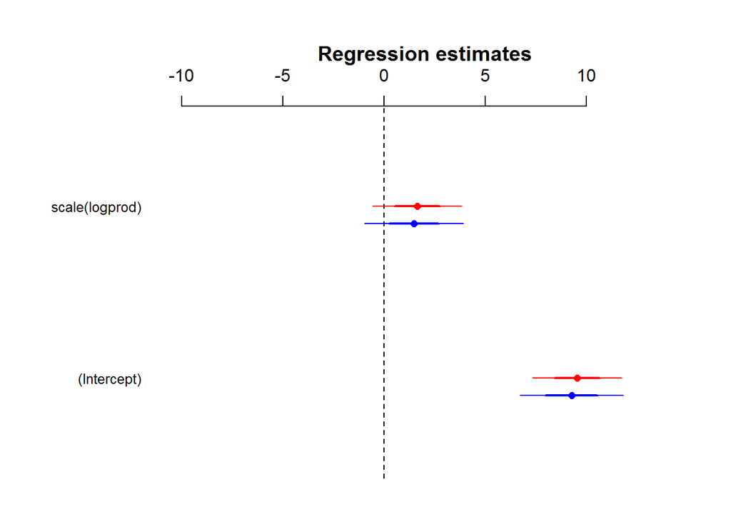

```r
# coef plots
mixmod.pois.beta.freq = exp(fixef(mixmod.pois))
mixmod.pois.se.freq = exp(sqrt(diag(vcov(mixmod.pois))))
mixmod.pois.beta.jags = exp(apply(all.beta,2,mean))
mixmod.pois.se.jags = exp(apply(all.beta,2, sd))

coefplot2(mixmod.pois.beta.freq, mixmod.pois.se.freq, col = "red",
          varnames = names(mod.beta.freq), xlim = c(-10,14))
coefplot2(mixmod.pois.beta.jags, mixmod.pois.se.jags, col = "blue",
          varnames = names(mod.beta.freq), add = TRUE, offset = -0.1)
```

Finally for a coefficient plot of all three models together…

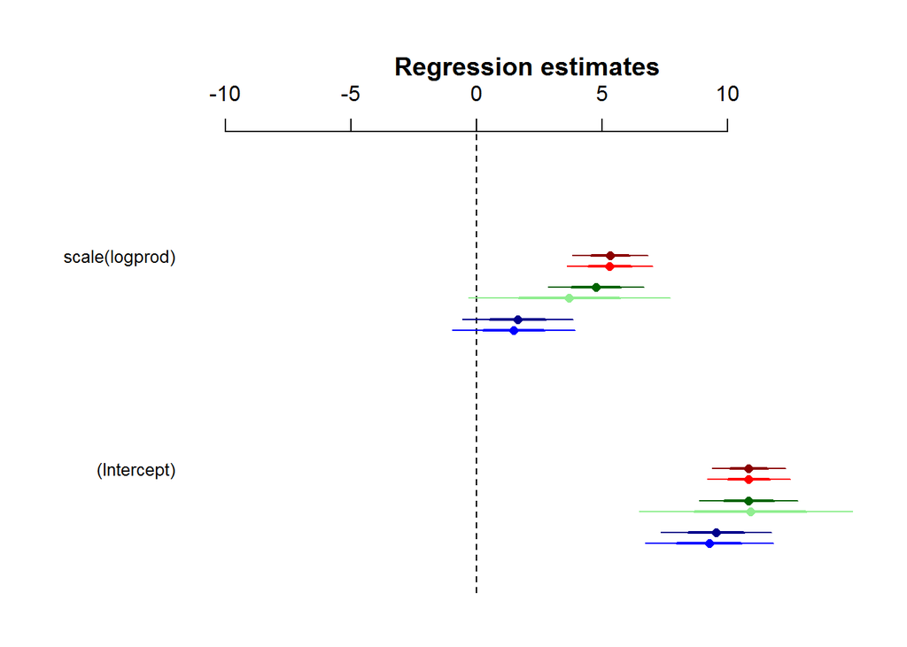

```r
coefplot2(mod.beta.freq, mod.se.freq, col = "darkred",
          varnames = names(mod.beta.freq), xlim = c(-10,14))
coefplot2(mod.beta.jags, mod.se.jags, col = "red",
          varnames = names(mod.beta.freq), add = TRUE, offset = -0.05)


coefplot2(mixmod.beta.freq, mixmod.se.freq, col = "darkgreen",
          varnames = names(mod.beta.freq), add = TRUE, offset = -0.15)
coefplot2(mixmod.beta.jags, mixmod.se.jags, col = "lightgreen",
          varnames = names(mod.beta.freq), add = TRUE, offset = -0.2)


coefplot2(mixmod.pois.beta.freq, mixmod.pois.se.freq, col = "darkblue",
          varnames = names(mod.beta.freq), add = TRUE, offset = -0.3)
coefplot2(mixmod.pois.beta.jags, mixmod.pois.se.jags, col = "blue",
          varnames = names(mod.beta.freq), add = TRUE, offset = -0.35)
```

For more on fitting models in a Bayesian framework in R, I highly recommend ‘[A Beginner’s Guide to GLM and GLMM with R](http://www.highstat.com/BGGLM.htm)’ by Zuur et al. and ‘[Introduction to WinBUGS for Ecologists](http://www.mbr-pwrc.usgs.gov/software/kerybook/)’ by Kery. The Zuur et al. book uses R2jags and comprises lots of useful examples based on real ecological datasets. The Kery book provides an excellent walk through from the basics through to more complex models (based on R2WinBUGS, but the code can easily be adapted to R2jags/JAGS).